# Infer ASVs with DADA2

Calla Bush St George

2024-05-03

## Before you start

### Set my seed

```r
# Any number can be chosen
# This tries to make any calculations with randomness replicable when rerun
set.seed(567890)
```

### Load Libraries

```r
# Efficient package loading with pacman
pacman::p_load(tidyverse, devtools, dada2, phyloseq, patchwork, DT,
               install = FALSE)
```

# Goals for this file

1. Use raw fastq and generate the quality plots to asses the quality of reads
2. Filter and trim out bad sequences and bases from our sequencing files
3. Write out fastq files with high quality sequences
4. Evaluate the quality from our filter and trim.
5. Infer errors on forward and reverse reads individually
6. Identified ASVs on forward and reverse reads separately using the error model.
7. Merge forward and reverse ASVs into “contigous ASVs”.
8. Generate ASV count table. (`otu_table` input for phyloseq.).

# Output that we need:

1. ASV count table: `otu_table`
2. Taxonomy table `tax_table`
3. Sample information: `sample_table` track the reads lost throughout DADA2 workflow.

## Load Data

```r
#Set the raw fastq path to the raw sequencing files
#Path to the fastq files
raw_fastqs_path <- "data/01_DADA2/01_raw_gzipped_fastqs"

#What files are in this path (Intuition check)
list.files(raw_fastqs_path)
```

```
##  [1] "568_4_S245_L001_R1_001.fastq.gz" "568_4_S245_L001_R2_001.fastq.gz"
##  [3] "568_5_S246_L001_R1_001.fastq.gz" "568_5_S246_L001_R2_001.fastq.gz"
##  [5] "581_5_S247_L001_R1_001.fastq.gz" "581_5_S247_L001_R2_001.fastq.gz"
##  [7] "611_5_S248_L001_R1_001.fastq.gz" "611_5_S248_L001_R2_001.fastq.gz"
##  [9] "E03_5_S146_L001_R1_001.fastq.gz" "E03_5_S146_L001_R2_001.fastq.gz"
## [11] "E05_5_S147_L001_R1_001.fastq.gz" "E05_5_S147_L001_R2_001.fastq.gz"
## [13] "E1_4_S140_L001_R1_001.fastq.gz"  "E1_4_S140_L001_R2_001.fastq.gz"
## [15] "E1_5_S141_L001_R1_001.fastq.gz"  "E1_5_S141_L001_R2_001.fastq.gz"
## [17] "E2_4_S142_L001_R1_001.fastq.gz"  "E2_4_S142_L001_R2_001.fastq.gz"
## [19] "E2_5_S143_L001_R1_001.fastq.gz"  "E2_5_S143_L001_R2_001.fastq.gz"
## [21] "E3_4_S144_L001_R1_001.fastq.gz"  "E3_4_S144_L001_R2_001.fastq.gz"
## [23] "E3_5_S145_L001_R1_001.fastq.gz"  "E3_5_S145_L001_R2_001.fastq.gz"
## [25] "Neg1_S148_L001_R1_001.fastq.gz"  "Neg1_S148_L001_R2_001.fastq.gz"
## [27] "Neg2_S249_L001_R1_001.fastq.gz"  "Neg2_S249_L001_R2_001.fastq.gz"
```

```r
#Create a vector of forward reads
forward_reads <- list.files(raw_fastqs_path, pattern = "_R1_001.fastq.gz",
                            full.names = TRUE)
#Intuition check
head(forward_reads)
```

```
## [1] "data/01_DADA2/01_raw_gzipped_fastqs/568_4_S245_L001_R1_001.fastq.gz"
## [2] "data/01_DADA2/01_raw_gzipped_fastqs/568_5_S246_L001_R1_001.fastq.gz"
## [3] "data/01_DADA2/01_raw_gzipped_fastqs/581_5_S247_L001_R1_001.fastq.gz"
## [4] "data/01_DADA2/01_raw_gzipped_fastqs/611_5_S248_L001_R1_001.fastq.gz"
## [5] "data/01_DADA2/01_raw_gzipped_fastqs/E03_5_S146_L001_R1_001.fastq.gz"
## [6] "data/01_DADA2/01_raw_gzipped_fastqs/E05_5_S147_L001_R1_001.fastq.gz"
```

```r
#Create a vector of reverse reads
reverse_reads <-list.files(raw_fastqs_path, pattern = "_R2_001.fastq.gz",
                           full.names = TRUE)
#Intuition check
head(reverse_reads)
```

```
## [1] "data/01_DADA2/01_raw_gzipped_fastqs/568_4_S245_L001_R2_001.fastq.gz"
## [2] "data/01_DADA2/01_raw_gzipped_fastqs/568_5_S246_L001_R2_001.fastq.gz"
## [3] "data/01_DADA2/01_raw_gzipped_fastqs/581_5_S247_L001_R2_001.fastq.gz"
## [4] "data/01_DADA2/01_raw_gzipped_fastqs/611_5_S248_L001_R2_001.fastq.gz"
## [5] "data/01_DADA2/01_raw_gzipped_fastqs/E03_5_S146_L001_R2_001.fastq.gz"
## [6] "data/01_DADA2/01_raw_gzipped_fastqs/E05_5_S147_L001_R2_001.fastq.gz"
```

```r
#Any duplicates between forward and reverse reads
any(duplicated(c(forward_reads, reverse_reads)))
```

```
## [1] FALSE
```

# Assess Raw Read Quality

## Evaluate raw sequence quality

Let’s see the quality of the raw reads *before* we trim

```r
# Look at all the reverse and forward reads
random_samples <- sample(1:length(reverse_reads), size = 14)
random_samples
```

```
##  [1]  6  1 14 12 11  4  9 10 13  7  2  8  3  5
```

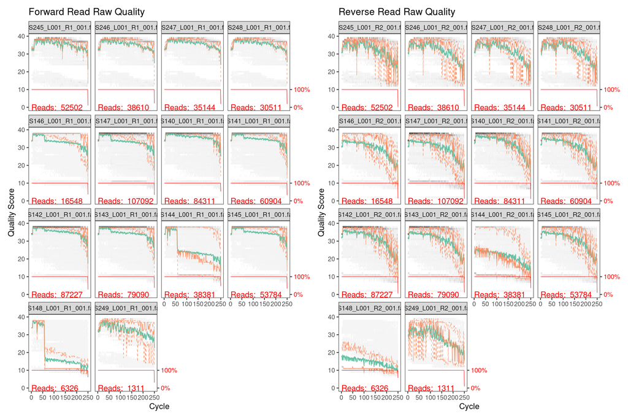

```r
# Calculate and plot quality of the samples
forward_filteredQual_plot_14 <-
  plotQualityProfile(forward_reads[random_samples]) +
  labs(title = "Forward Read Raw Quality")

reverse_filteredQual_plot_14 <-
  plotQualityProfile(reverse_reads[random_samples]) +
  labs(title = "Reverse Read Raw Quality")

# Plot them together with patchwork
forward_filteredQual_plot_14 + reverse_filteredQual_plot_14
```

### Aggregated Raw Quality Plots

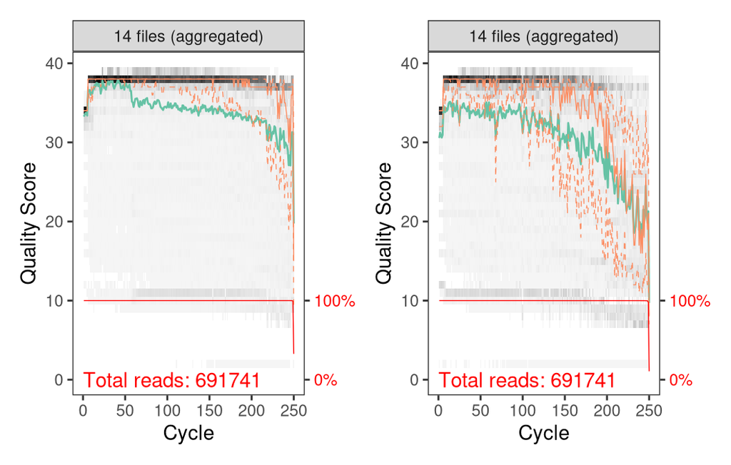

```r
# Aggregate all QC plots
plotQualityProfile(forward_reads, aggregate = TRUE) +
  plotQualityProfile(reverse_reads, aggregate = TRUE)
```